# Лабораторная работа №7

Операционные системы

Лебеденко Е.В.

Российский университет дружбы народов, Москва, Россия

28 марта 2026

# Информация

## Докладчик

- Лебеденко Елена Викторовна
- Студент НКАбд-04-25
- Российский университет дружбы народов
- 1032253535@rudn.ru

# Цель работы

Ознакомление с файловой системой Linux, её структурой, именами и содержанием каталогов. Приобретение практических навыков по применению команд для работы с файлами и каталогами, по управлению процессами (и работами), по проверке использования диска и обслуживанию файловой системы.

# Задание

1. Выполните все примеры, приведённые в первой части описания лабораторной работы.
2. Выполните следующие действия, зафиксировав в отчёте по лабораторной работе используемые при этом команды и результаты их выполнения
3. Определите опции команды chmod, необходимые для того, чтобы присвоить перечис- ленным ниже файлам выделенные права доступа, считая, что в начале таких прав нет
4. Проделайте приведённые ниже упражнения, записывая в отчёт по лабораторной работе используемые при этом команды
5. Прочитайте man по командам mount, fsck, mkfs, kill и кратко их охарактеризуйте, приведя примеры.

# Теоретическое введение

Для создания текстового файла можно использовать команду touch. Формат команды: - touch имя-файла Для просмотра файлов небольшого размера можно использовать команду cat. Формат команды: - cat имя-файла

# Выполнение лабораторной работы

. Выполните все примеры, приведённые в первой части описания лабораторной работы.

Копирую файл ~/abc1 в файл april и в файл may

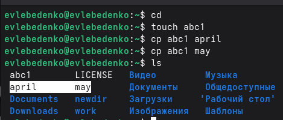

Копирование файла в текущем каталоге

Копирую файлы april и may в каталог monthly

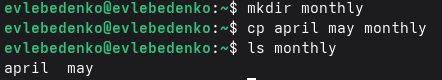

Копирование нескольких файлов в каталог

Копирую файл monthly/may в файл с именем june

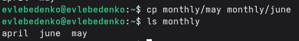

Копирование файлов в произвольном каталоге

Копирую каталог monthly в каталог monthly.00

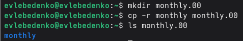

Копирование каталогов в текущем каталоге

Копирую каталог monthly.00 в каталог /tmp

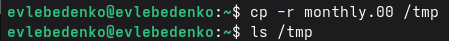

Копирование каталогов в произвольном каталоге

[output not shown]

Перемещаю файл july в каталог monthly.00

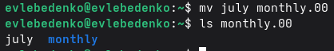

Перемещение файлов в другой каталог

Переименовываю каталог monthly.00 в monthly.01

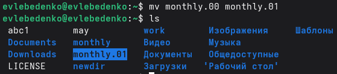

Переименование каталогов в текущем каталоге

Перемещаю каталог monthly.01в каталог reports

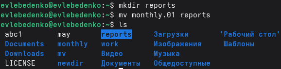

Перемещение каталога в другой каталог

Переименовываю каталог reports/monthly.01 в reports/monthly

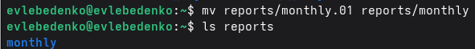

Переименование каталога, не являющегося текущим

Создаю файл ~/may с правом выполнения для владельца, лишаю владельца файла ~/may права на выполнение

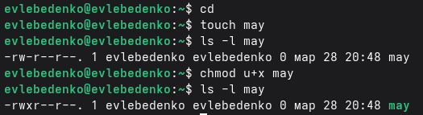

Добавление и лишение прав доступа владельца

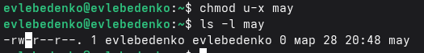

Создаю файл ~/abc1 с правом записи для членов группы

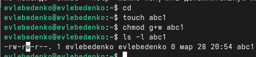

Добавление прав доступа группе

2. Выполните следующие действия, зафиксировав в отчёте по лабораторной работе используемые при этом команды и результаты их выполнения

Копирую файл /usr/include/sys/io.h в домашний каталог и называю его equipment.

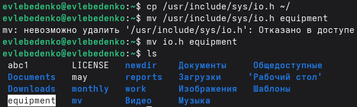

2.1

В домашнем каталоге создаю директорию ~/ski.plases. Перемещаю файл equipment в каталог ~/ski.plases.

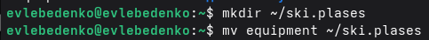

2.2 и 2.3

Переименовываю файл ~/ski.plases/equipment в ~/ski.plases/equiplist.

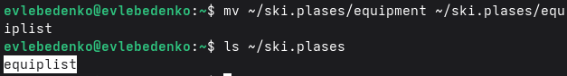

2.4

ССоздаю в домашнем каталоге файл abc1 и копирую его в каталог ~/ski.plases, называю его equiplist2.

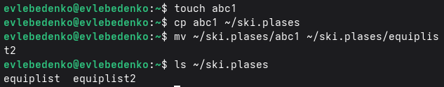

2.5

Создаю каталог с именем equipment в каталоге ~/ski.plases, перемещаю файлы ~/ski.plases/equiplist и equiplist2 в каталог ~/ski.plases/equipment.

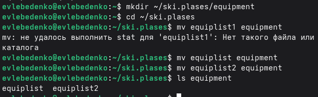

2.6 и 2.7

Создаю и перемещаю каталог ~/newdir в каталог ~/ski.plases и назоваю его plans.

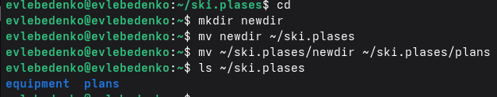

2.8

3. Определите опции команды chmod, необходимые для того, чтобы присвоить перечисленным ниже файлам выделенные права доступа, считая, что в начале таких прав нет:
- 3.1. drwxr–r– … australia
- 3.2. drwx–x–x … play
- 3.3. -r-xr–r– … my_os
- 3.4. -rw-rw-r– … feathers

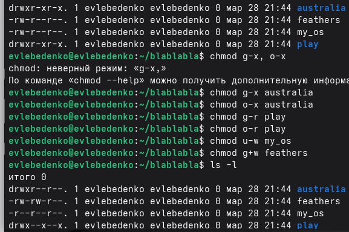

Управление правами доступа

4. Проделайте приведённые ниже упражнения, записывая в отчёт по лабораторной работе используемые при этом команды

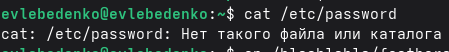

4.1

Копирую файл ~/feathers в файл ~/file.old, перемещаю файл ~/file.old в каталог ~/play

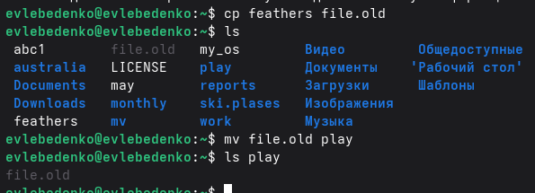

4.2 и 4.3

Копирую каталог ~/play в каталог ~/fun, перемещаю каталог ~/fun в каталог ~/play и называю его games

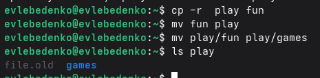

4.4 и 4.5

Лишаю владельца файла ~/feathers права на чтение.

Что произойдёт, если вы попытаетесь просмотреть файл ~/feathers командой cat? Что произойдёт, если вы попытаетесь скопировать файл ~/feathers?

В обоих случаях отказывает в доступе

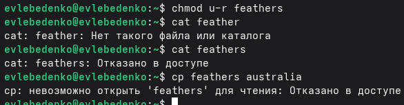

4.6-4.8

Даю владельцу файла ~/feathers право на чтение. Лишаю владельца каталога ~/play права на выполнение. Перехожу в каталог ~/play. Что произошло?

Отказано в доступе

Даю владельцу каталога ~/play право на выполнение.

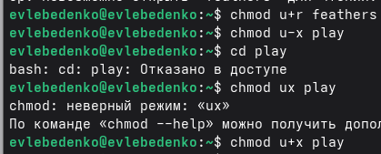

4.9-4.12

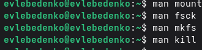

man

# Выводы

Во время выполнения лабораторной работы я приобрела практические навыки взаимодействия пользователя с файловой системой Linux посредством командной строки.